# Logo quality predicting companies’ revenues

# Abstract

# The dataset

**Figure 1**

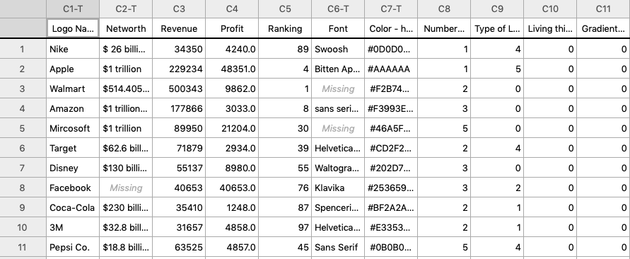

# Data Cleaning

The testing of our data is going to be done in R Studio and also in JUMP. However the cleaning of the data was being done by using R. We want to create a cleaner data set therefore it would be much easier to use in R Studio. By cleaning the data-set it made it much easier to find the outliers in the data. By running the following code we were able to plot the data point and see which data were the outliers. Using the Z-score that were greater than `3.29` we found that there were 57 outliers. But when we actually plot it we can see that there is actually less outliers as it shown in figure 2. This could be possible because our data set does have some companies that have a larger profit than the others.

```r
library(dplyr)
library(readr)

logorev <- read_csv("logorev.csv")
View(logorev)
attach(logorev)
```

#### Renamining

We would like to create a cleaner data set, and make the name of the variable easy to read and without space so it will be easire to call them in `R`.

```r
logorev_cleaned <- logorev
names(logorev)
```

```
##  [1] "Logo Names"               "Networth"
##  [3] "Revenue"                  "Profit"
##  [5] "Ranking"                  "Font"
##  [7] "Color - hex #"            "Number of Colors"
##  [9] "Type of Logo"             "Living thing in the logo"
## [11] "Gradient (y,n)"
```

```r
logorev_cleaned <- logorev_cleaned %>%
  rename(`Name` = `Logo Names`, `Colors` = `Color - hex #`, `Number_of_colors` = `Number of Colors`, `Type_of_logo` = `Type of Logo`, `Living_in_logo` = `Living thing in the logo`, `Gradient` = `Gradient (y,n)`)
```

#### Variables Type

Because the variable `Gradient` and `Living in logo` are dichotomus variables we need to transform them as factors.

```r
### Making variables from numeric to factor
cols <- c('Gradient', 'Living_in_logo')
logorev_cleaned[cols] <- lapply(logorev_cleaned[cols], as.factor)
```

#### Outliers

From the z scorse greate than `3.29` we can see that there are 57 outliers, but in the boxplot we would see that there actually less outliers. We although have some big companies that have larger profit than others.The variabilieties within cases is very large and only few companies have higher profit than other. We will need to consider this characteristic of our dataset later in our Analysis.

```r
attach(logorev_cleaned)
```

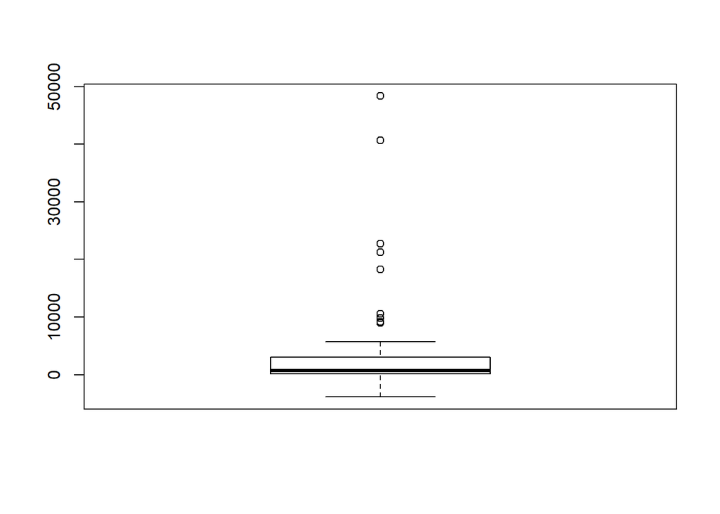

```r
boxplot(Profit)
```

```r
sum(abs(Profit - mean(Profit)/ sd(Profit)) > 3.29)
```

```
## [1] 57
```

From the boxplot we can clearly see that there is a company that have a revenue greater than 400000 which is Walmart. So we might need to take in consideration this in our Analysis that there are some Companies’ revenue that might influence the results.

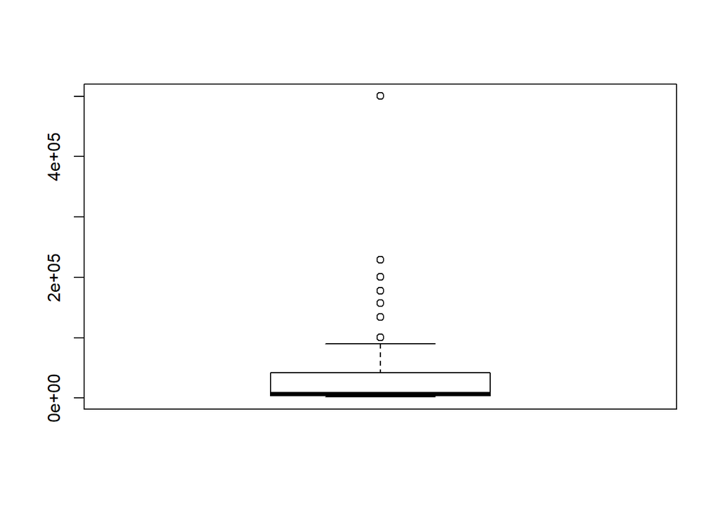

```r
boxplot(Revenue)
```

```r
sum(abs(Revenue - mean(Revenue)/ sd(Revenue)) > 3.29)
```

```
## [1] 57
```

For the variable `Ranking` we have almost all of the cases layed as outliers for the rule of Z-scores greater than 3.29. The boxplot shows that there are not any outliers. This discrepancy is related to the fact that we have large variances between the datapoints.

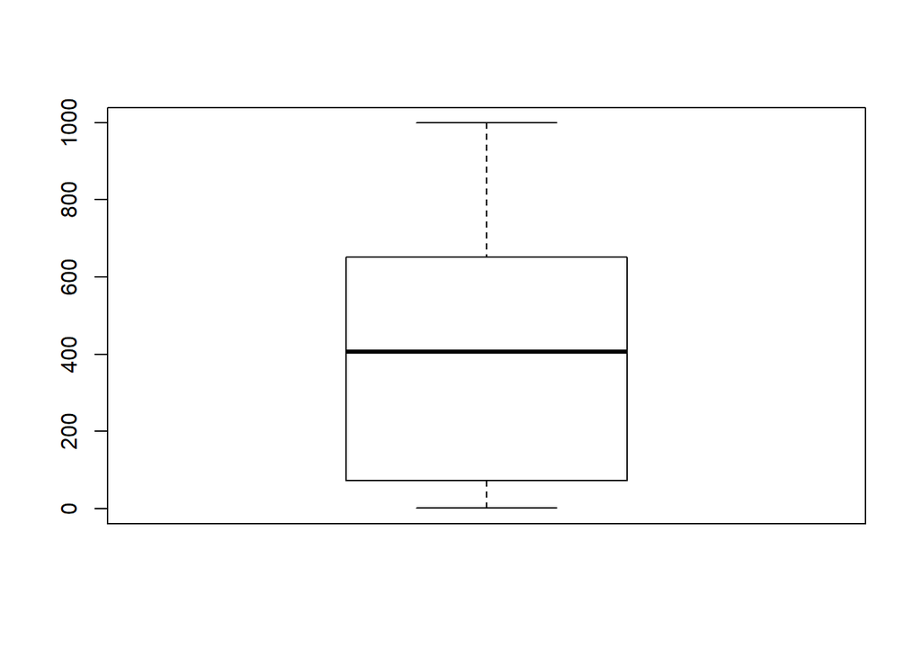

```r
boxplot(Ranking)
```

```r
sum(abs(Ranking - mean(Ranking)/ sd(Ranking)) > 3.29)
```

```
## [1] 55
```

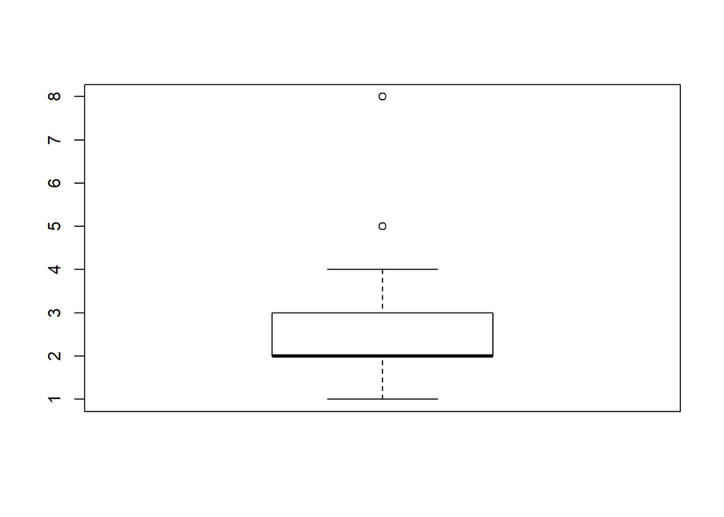

```r
boxplot(Number_of_colors)
```

```r
sum(abs(Number_of_colors - mean(Number_of_colors)/ sd(Number_of_colors)) > 3.29)
```

```
## [1] 7
```

#### Missing Values

We have not contiunued to input in our dataset the `networth` variable and the `font` variable, so those variables will have missing values.

# Assumptions

For deciding what would be the best way to predict profits or revenue of a company based on their Logo characteristic we would need to check the conditions of Linearity, Independence, Normality, Equality of Variance and if we have multicollinear variables. This way we can better understand our variable and how to use them in our Analysis.

#### Linearity:

As expected the scotterplot for the variable `Ranking` shows a positive path and it look like it is well randomly spread. The `Profit` variable shows in the scatterplot that there are some outlies because of high leverage because fare away from the companies that have a lower profit. It could be helpful to consider to transform the variable. `Revenue`’s scatterplot also indicates that there are significant outliers and it looks like a logarithmic transformation is needed because it shows a parabolic shape in the distribution of the data points.

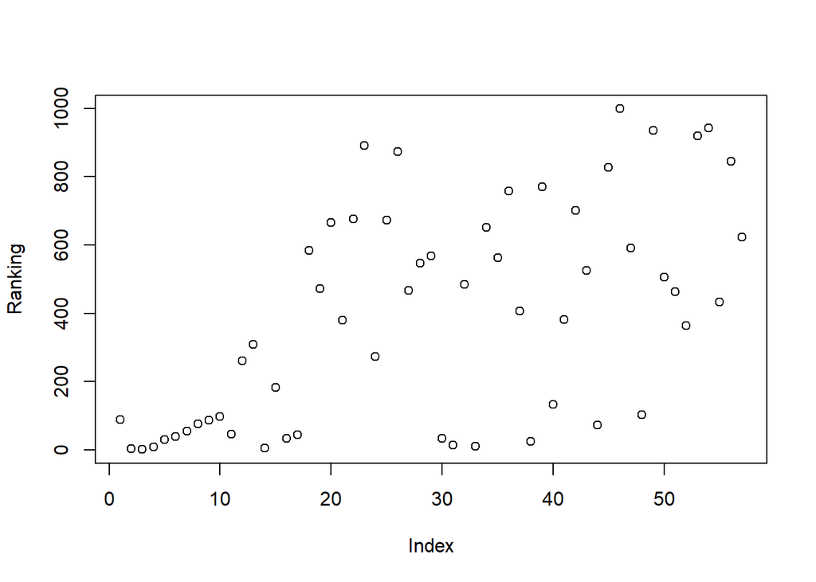

```r
plot(Ranking)
```

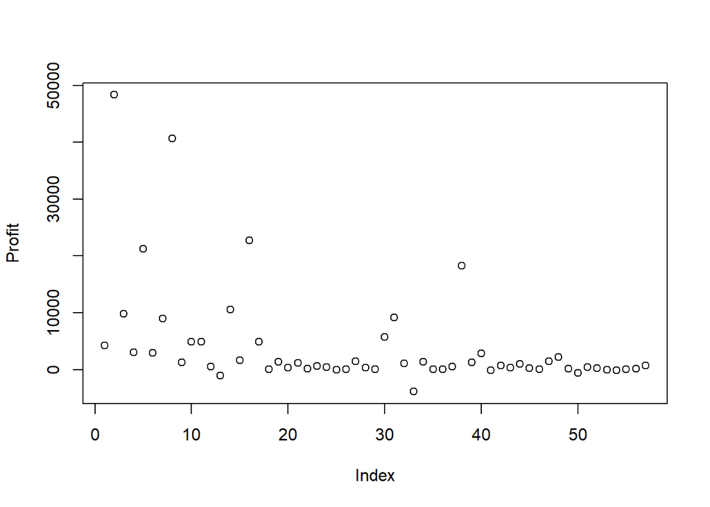

```r
plot(Profit)
```

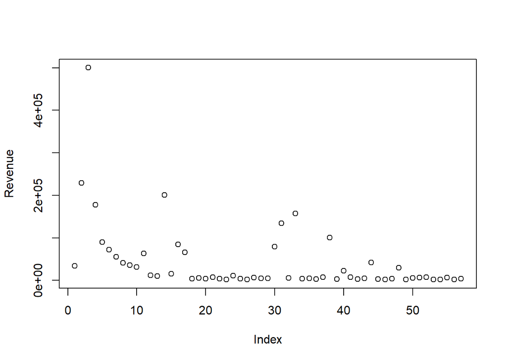

```r
plot(Revenue)
```

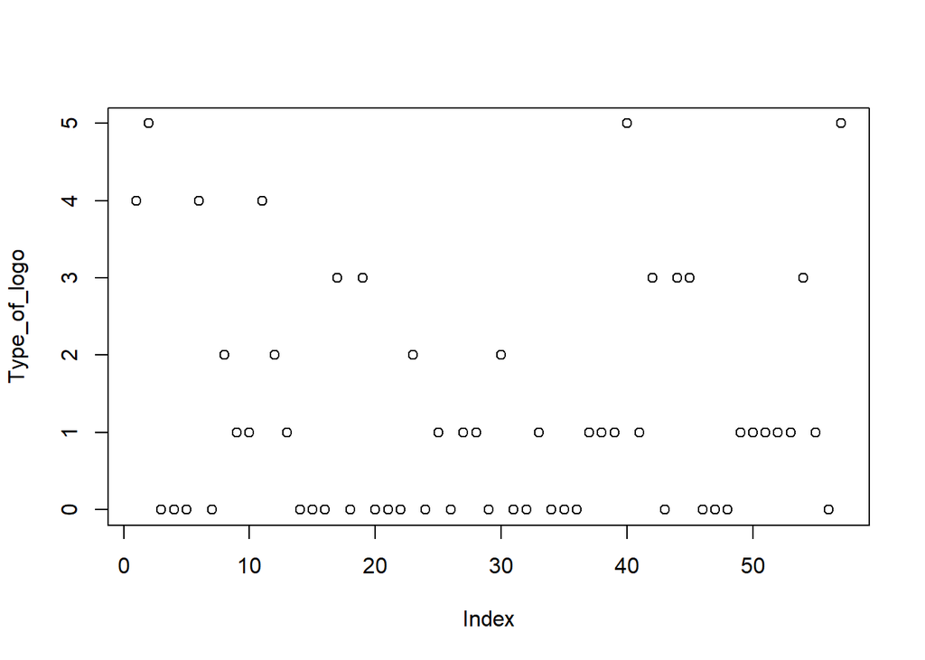

```r
plot(Type_of_logo)
```

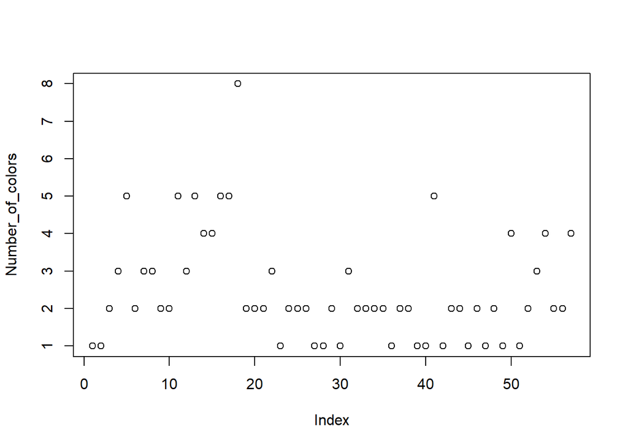

```r
plot(Number_of_colors)
```

If we try to plot more variables togheter to see which variables can have the best path in a scatterplot we can see that `Revenue` and `Ranking` have a parabolic shape and therefore it might need some transformation. The scatterplot of the relation between `Revenue` and `Profit` is not very defined since there are some outliers, but oversoall it looks to have a weak and positive relationship. The relationship between `Number of colors` and `Revenue` is very interesting since we do not have any linear pattern, but it looks like that the variablity is larger when there are less colors. We cannot state this without analyze the data more deeply. Overall we do not see any linear pattern.

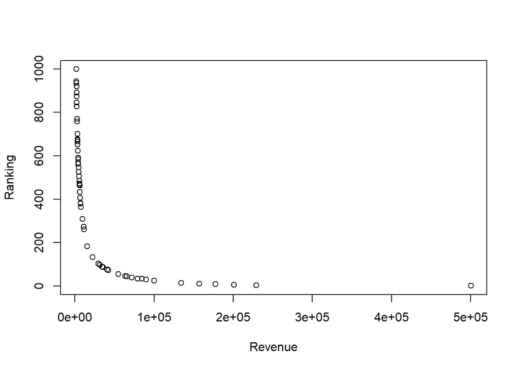

```r
plot(Revenue, Ranking)
```

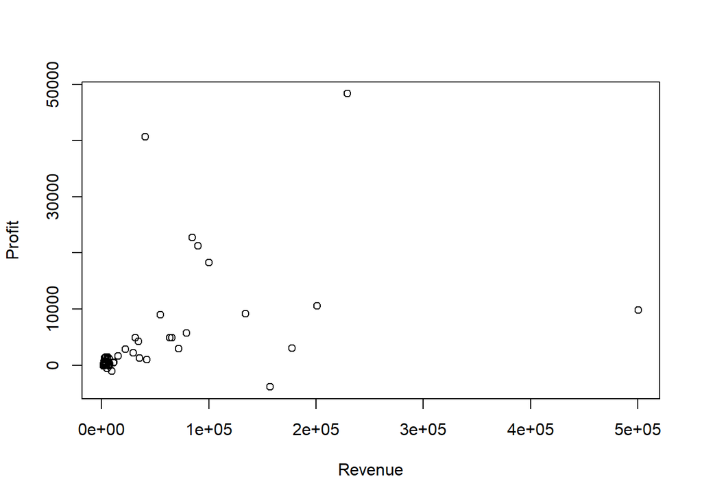

```r
plot(Revenue, Profit)
```

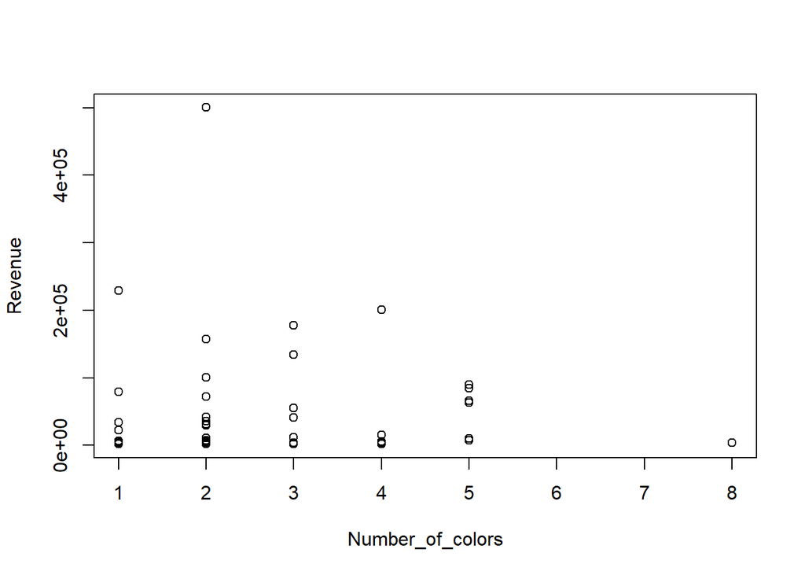

```r
plot(Number_of_colors, Revenue)
```

#### Independence:

We assume that our data come from a indpendent sample where given one variable we do not know anything about another variable. This is true, infact, for all our variables.

#### Normality:

From the histogram of the distribution of our variables of `Ranking`, `Profit`, `Revenue`, `Number Of Colors` and `Type of logo` we can state that all of these variables are not normally distributed because they are skewed right.

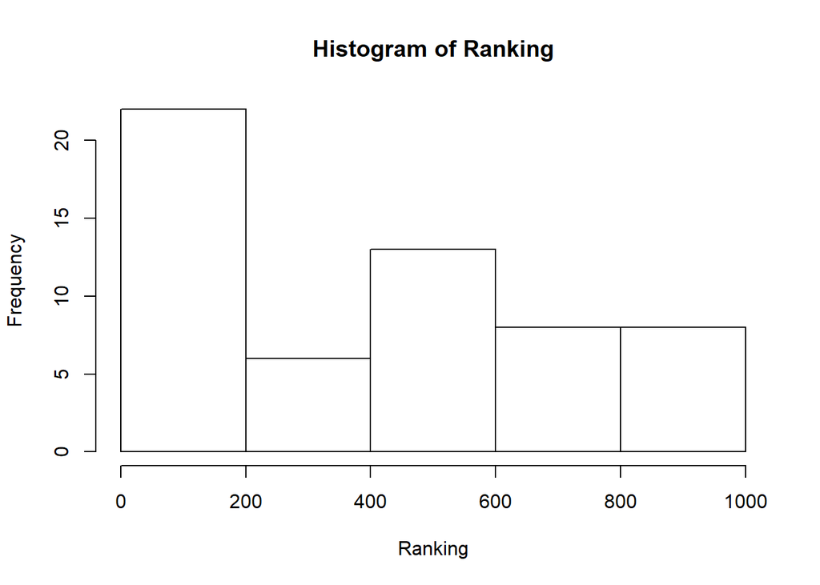

```r
library(moments)

hist(Ranking)
```

```r
skewness(Ranking)
```

```
## [1] 0.2358989
```

```r
kurtosis(Ranking)
```

```
## [1] 1.733534
```

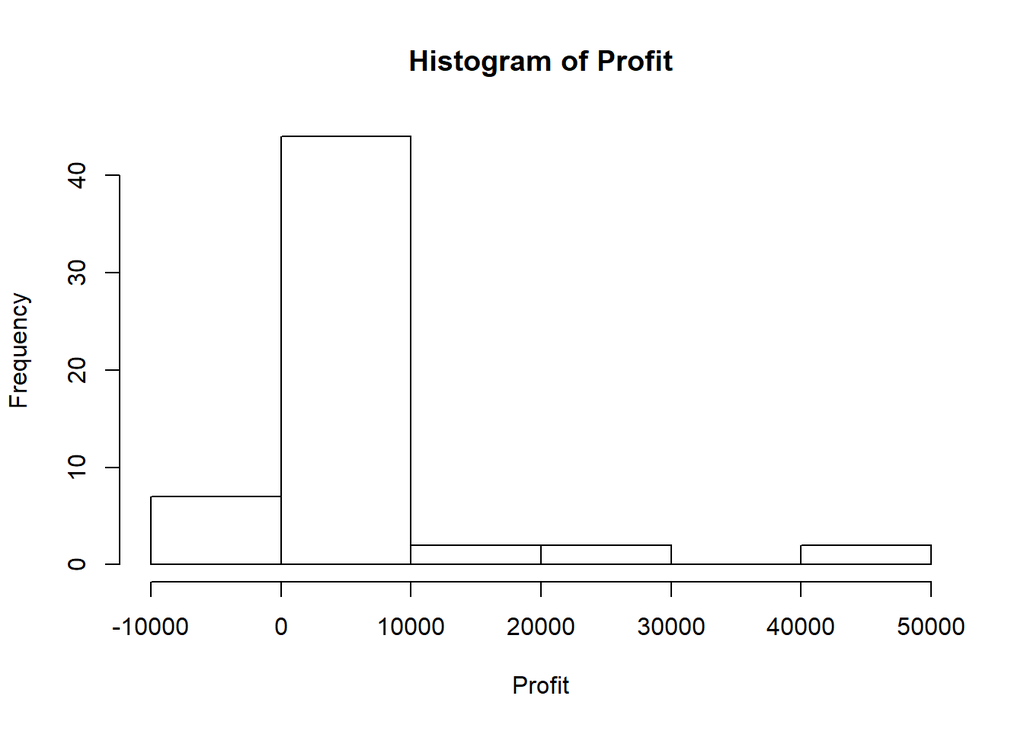

```r
hist(Profit)
```

```r
skewness(Profit)
```

```
## [1] 3.277405
```

```r
kurtosis(Profit)
```

```
## [1] 14.11682
```

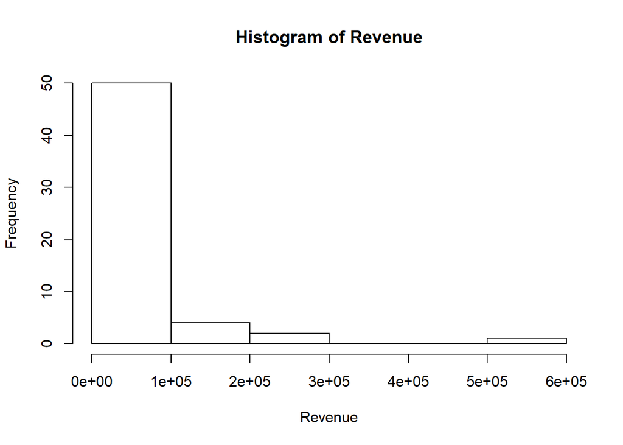

```r
hist(Revenue)
```

```r
skewness(Revenue)
```

```
## [1] 3.650869
```

```r
kurtosis(Revenue)
```

```
## [1] 19.13349
```

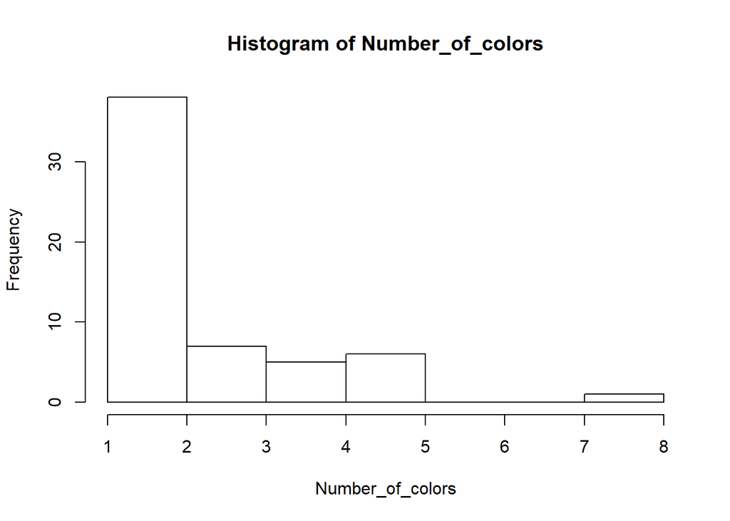

```r
hist(Number_of_colors)
```

```r
skewness(Number_of_colors)
```

```
## [1] 1.391956
```

```r
kurtosis(Number_of_colors)
```

```
## [1] 5.188652
```

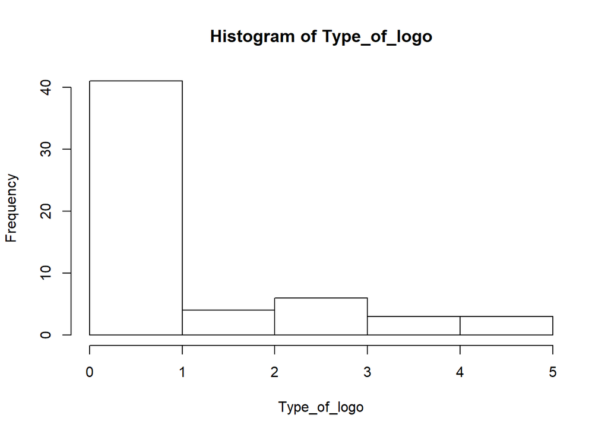

```r
hist(Type_of_logo)
```

```r
skewness(Type_of_logo)
```

```
## [1] 1.177559
```

```r
kurtosis(Type_of_logo)
```

```
## [1] 3.332914
```

#### Equality Of Variance:

For assessing we would need to find the residuals for each variable.

#### Multicollinearity & Singularity:

By looking at the covariance matrix we do not have any correlations abot 0.7, which means that we do not have any Multicollinearity. We do not have any correlations between variables that are greater than 1, so we do not have Singularity.

```r
round(cor(cbind(Ranking, Profit, Revenue, Number_of_colors, Type_of_logo, Living_in_logo, Gradient)),3)
```

```
##                  Ranking Profit Revenue Number_of_colors Type_of_logo
## Ranking            1.000 -0.471  -0.565           -0.206       -0.153
## Profit            -0.471  1.000   0.443            0.085        0.203
## Revenue           -0.565  0.443   1.000            0.048        0.000
## Number_of_colors  -0.206  0.085   0.048            1.000       -0.100
## Type_of_logo      -0.153  0.203   0.000           -0.100        1.000
## Living_in_logo    -0.078 -0.080  -0.091           -0.043        0.283
## Gradient           0.000 -0.063  -0.041            0.199       -0.132
##                  Living_in_logo Gradient
## Ranking                  -0.078    0.000
## Profit                   -0.080   -0.063
## Revenue                  -0.091   -0.041
## Number_of_colors         -0.043    0.199
## Type_of_logo              0.283   -0.132
## Living_in_logo            1.000   -0.085
## Gradient                 -0.085    1.000
```

# Analysis

```r
head(logorev_cleaned)
```

```
## # A tibble: 6 x 11
##   Name  Networth Revenue Profit Ranking Font  Colors Number_of_colors
##   <chr> <chr>      <dbl>  <dbl>   <dbl> <chr> <chr>             <dbl>
## 1 Nike  "$ 26 b~   34350   4240      89 Swoo~ #0D0D~                1
## 2 Apple "$1 tri~  229234  48351       4 Bitt~ #AAAA~                1
## 3 Walm~ "$514.4~  500343   9862       1 <NA>  #F2B7~                2
## 4 Amaz~ "$1 tri~  177866   3033       8 sans~ #F399~                3
## 5 Mirc~ "$1 tri~   89950  21204      30 <NA>  #46A5~                5
## 6 Targ~ "$62.6 ~   71879   2934      39 Helv~ #CD2F~                2
## # ... with 3 more variables: Type_of_logo <dbl>, Living_in_logo <fct>,
## #   Gradient <fct>
```

```r
summary(logorev_cleaned)
```

```
##      Name             Networth            Revenue           Profit
##  Length:57          Length:57          Min.   :  1849   Min.   :-3864.0
##  Class :character   Class :character   1st Qu.:  3574   1st Qu.:  107.3
##  Mode  :character   Mode  :character   Median :  6939   Median :  743.4
##                                        Mean   : 42656   Mean   : 4190.7
##                                        3rd Qu.: 42151   3rd Qu.: 3033.0
##                                        Max.   :500343   Max.   :48351.0
##     Ranking        Font              Colors          Number_of_colors
##  Min.   :  1   Length:57          Length:57          Min.   :1.000
##  1st Qu.: 72   Class :character   Class :character   1st Qu.:2.000
##  Median :407   Mode  :character   Mode  :character   Median :2.000
##  Mean   :395                                         Mean   :2.474
##  3rd Qu.:652                                         3rd Qu.:3.000
##  Max.   :999                                         Max.   :8.000
##   Type_of_logo   Living_in_logo Gradient
##  Min.   :0.000   0:53           0:52
##  1st Qu.:0.000   1: 4           1: 5
##  Median :1.000
##  Mean   :1.228
##  3rd Qu.:2.000
##  Max.   :5.000
```

## Decision Tree

A quick and easy decision Tree using `R`.

```r
# Loading the libraries
library(MASS)
library(rpart)
```

```r
mean(Revenue)
```

```
## [1] 42655.53
```

```r
median(Revenue)
```

```
## [1] 6939
```

```r
logorev_cleaned[,'top_company'] <- ifelse(Revenue >= 6939, 1, 0)
```

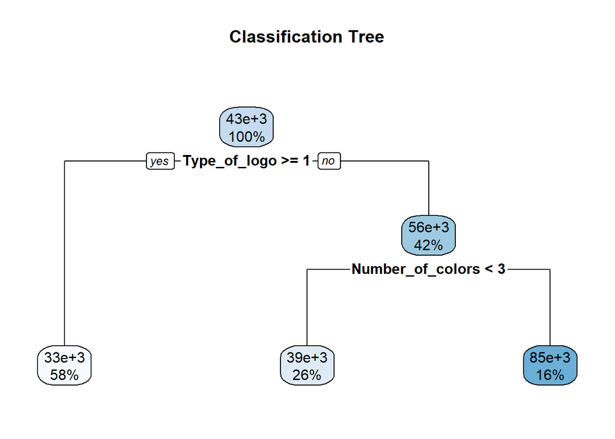

```r
### Making the
library(rpart.plot)
set.seed(1)
train <- sample(1:nrow(logorev_cleaned), 0.75 * nrow(logorev_cleaned))

logoTree <- rpart(Revenue ~ Type_of_logo + Number_of_colors + Living_in_logo + Gradient, data = logorev_cleaned)

rpart.plot(logoTree, main="Classification Tree")
```

```r
summary(logoTree)
```

```
## Call:
## rpart(formula = Revenue ~ Type_of_logo + Number_of_colors + Living_in_logo +
##     Gradient, data = logorev_cleaned)
##   n= 57
##
##           CP nsplit rel error   xerror      xstd
## 1 0.02657677      0 1.0000000 1.062557 0.5904755
## 2 0.01000000      2 0.9468465 1.173482 0.6632139
##
## Variable importance
## Number_of_colors     Type_of_logo         Gradient
##               56               36                8
##
## Node number 1: 57 observations,    complexity param=0.02657677
##   mean=42655.53, MSE=6.522562e+09
##   left son=2 (33 obs) right son=3 (24 obs)
##   Primary splits:
##       Type_of_logo     < 0.5 to the right, improve=0.021274340, (0 missing)
##       Number_of_colors < 1.5 to the left,  improve=0.009717432, (0 missing)
##   Surrogate splits:
##       Number_of_colors < 1.5 to the left,  agree=0.596, adj=0.042, (0 split)
##       Gradient         splits as  LR,      agree=0.596, adj=0.042, (0 split)
##
## Node number 2: 33 observations
##   mean=32609.7, MSE=2.42692e+09
##
## Node number 3: 24 observations,    complexity param=0.02657677
##   mean=56468.54, MSE=1.182451e+10
##   left son=6 (15 obs) right son=7 (9 obs)
##   Primary splits:
##       Number_of_colors < 2.5 to the left,  improve=0.04176439, (0 missing)
##   Surrogate splits:
##       Gradient splits as  LR, agree=0.667, adj=0.111, (0 split)
##
## Node number 6: 15 observations
##   mean=39255, MSE=1.52302e+10
##
## Node number 7: 9 observations
##   mean=85157.78, MSE=4.831433e+09
```

## Decision tree using JUMP

First, we did our full data decision tree analysis using JMP Pro 15. We saw one data that was way up high, and the difference between each child doesn’t seem to be really significant. We were concerned that this data point would extremely skew our data. Therefore, we deleted this data point.

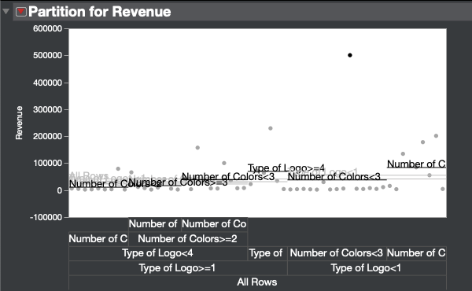

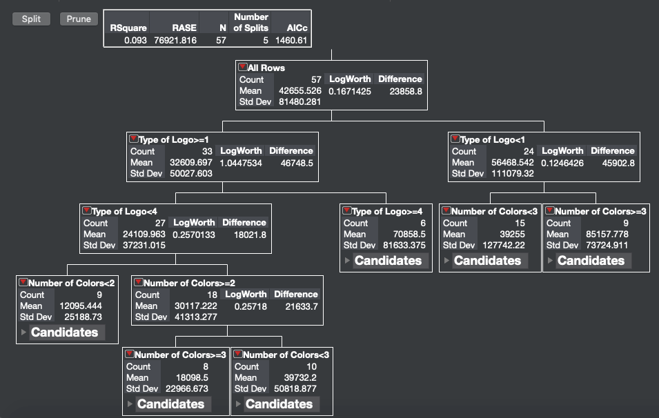

Our second decision tree analysis, after throwing out one outlier, looked so much better even though most data points are at the lower end of revenue and few data points scattered across the middle and higher end of revenue. Additionally, the children’s partitions seemed to be more defined.

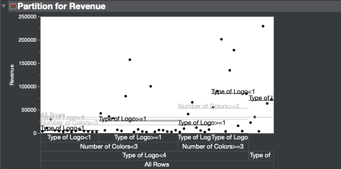

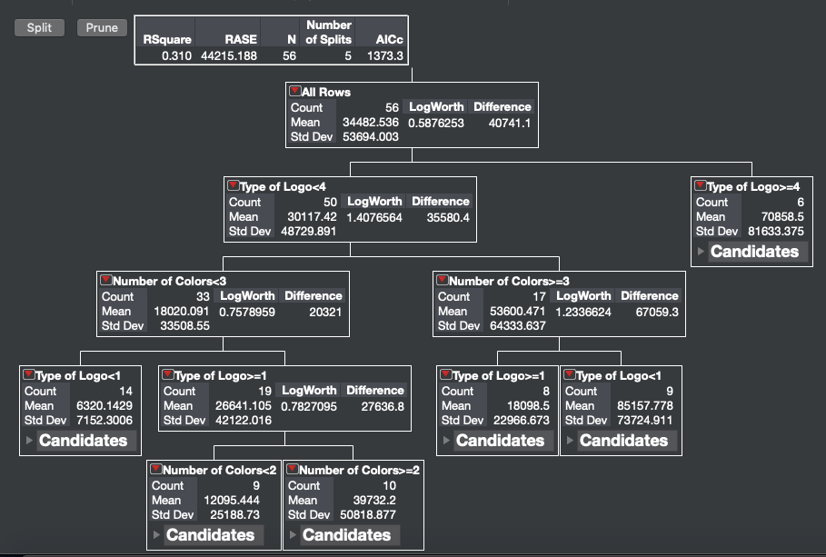

From both decision tree analysis, we can conclude that it is more likely for a company to have a higher revenue if their type of logo is a combination logo and between 3 and 5 number of colors.

## Multiple regression

#### Multiple regression

```r
multiple_regression = lm(Revenue ~ Type_of_logo + Number_of_colors, data = logorev_cleaned)

summary(multiple_regression)
```

```
##
## Call:
## lm(formula = Revenue ~ Type_of_logo + Number_of_colors, data = logorev_cleaned)
##
## Residuals:
##    Min     1Q Median     3Q    Max
## -53037 -36692 -33917    328 459273
##
## Coefficients:
##                  Estimate Std. Error t value Pr(>|t|)
## (Intercept)         35677      24475   1.458    0.151
## Type_of_logo          251       7480   0.034    0.973
## Number_of_colors     2697       7662   0.352    0.726
##
## Residual standard error: 82880 on 54 degrees of freedom
## Multiple R-squared:  0.002289,   Adjusted R-squared:  -0.03466
## F-statistic: 0.06194 on 2 and 54 DF,  p-value: 0.94
```

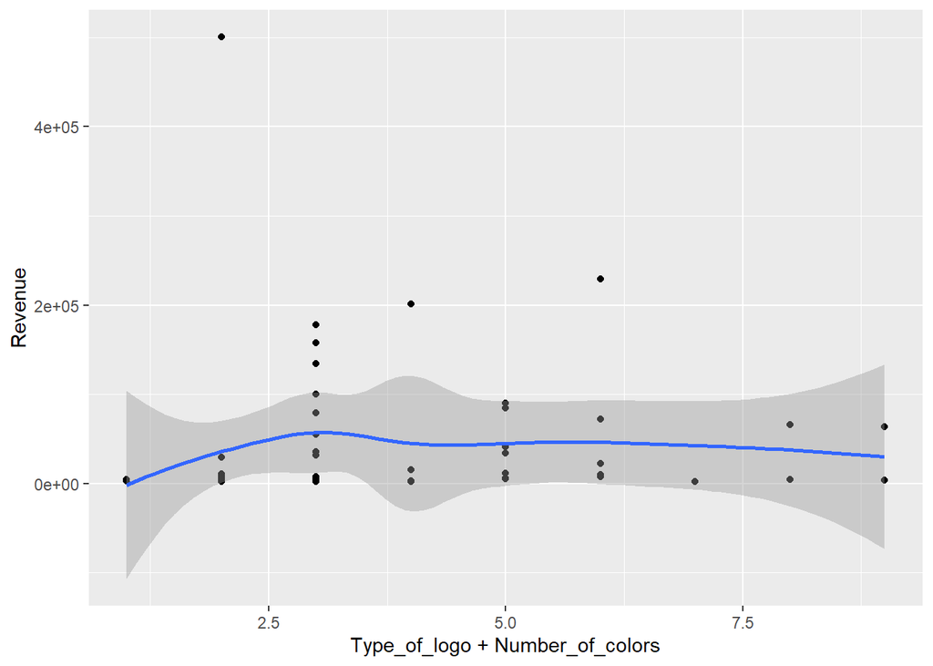

```r
ggplot(logorev_cleaned, aes(x=Type_of_logo + Number_of_colors, y=Revenue)) +
  geom_point()+
  geom_smooth()
```

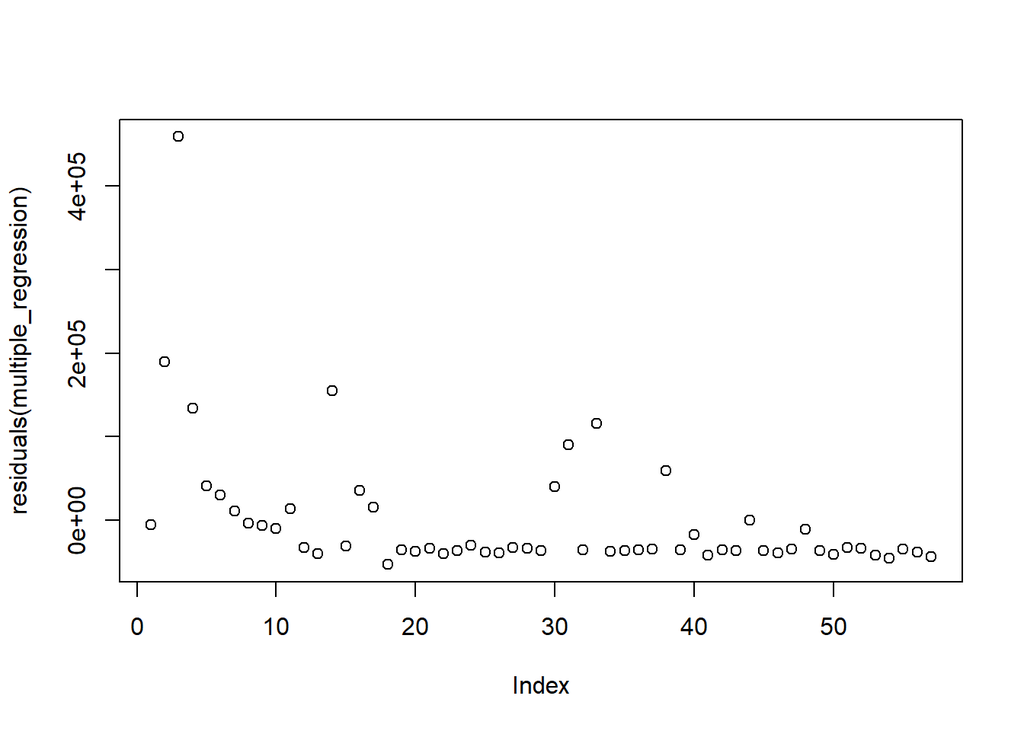

```r
plot(residuals(multiple_regression))
```

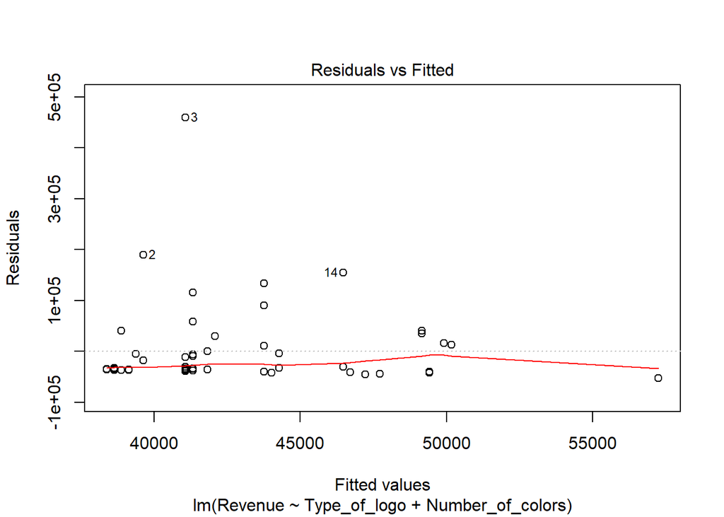

```r
plot(multiple_regression, which = 1)
```

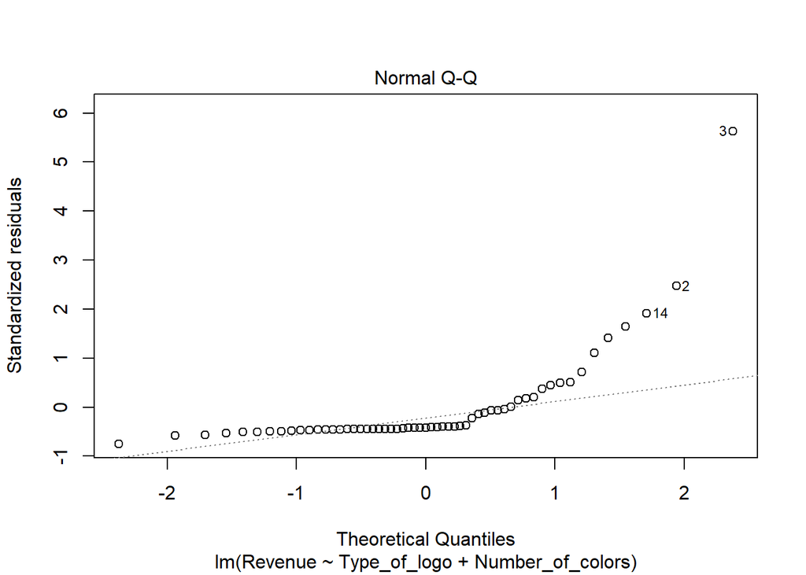

```r
plot(multiple_regression, which = 2)
```

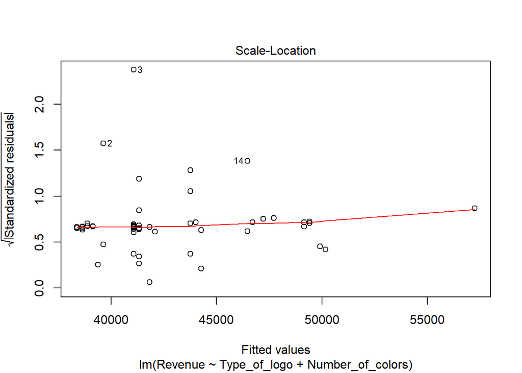

```r
plot(multiple_regression, which = 3)
```

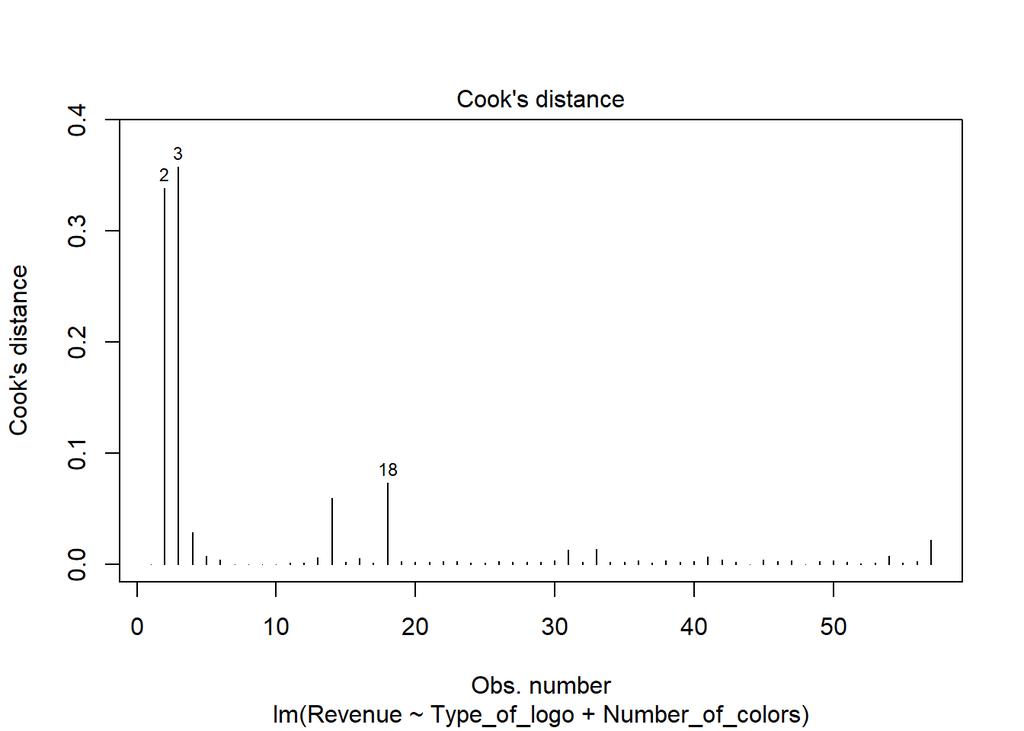

```r
plot(multiple_regression, which = 4)
```

```r
multiple_regression_2 = lm(log(Revenue + min(Revenue)) ~ log(Type_of_logo + 1) + log(Number_of_colors + 1), data = logorev_cleaned)

summary(multiple_regression_2)
```

```
##
## Call:
## lm(formula = log(Revenue + min(Revenue)) ~ log(Type_of_logo +
##     1) + log(Number_of_colors + 1), data = logorev_cleaned)
##
## Residuals:
##     Min      1Q  Median      3Q     Max
## -1.9779 -0.9829 -0.4870  0.8659  3.6543
##
## Coefficients:
##                           Estimate Std. Error t value Pr(>|t|)
## (Intercept)                 8.6060     0.6406  13.434   <2e-16 ***
## log(Type_of_logo + 1)       0.2703     0.2955   0.915    0.364
## log(Number_of_colors + 1)   0.7887     0.4773   1.652    0.104
## ---
## Signif. codes:  0 '***' 0.001 '**' 0.01 '*' 0.05 '.' 0.1 ' ' 1
##
## Residual standard error: 1.328 on 54 degrees of freedom
## Multiple R-squared:  0.05497,    Adjusted R-squared:  0.01997
## F-statistic: 1.571 on 2 and 54 DF,  p-value: 0.2173
```

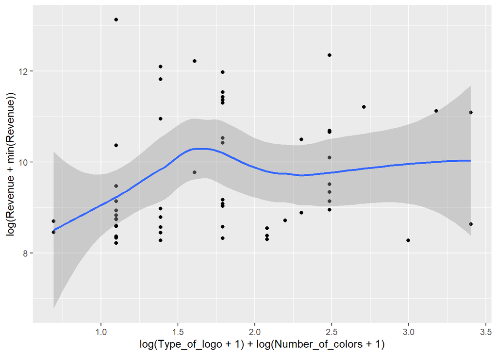

```r
ggplot(logorev_cleaned, aes(x=log(Type_of_logo + 1) + log(Number_of_colors + 1), y= log(Revenue + min(Revenue)))) +
  geom_point()+
  geom_smooth()
```

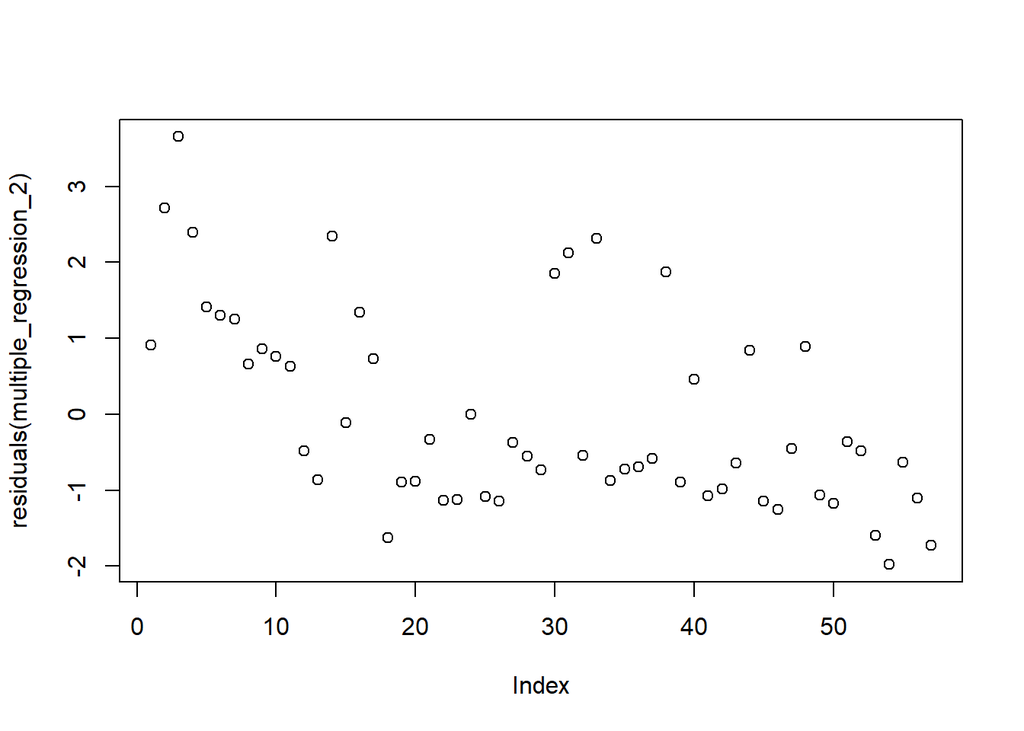

```r
plot(residuals(multiple_regression_2))
```